# Simultaneous Detection of Gradual and Abrupt Structural Changes in Bayesian Longitudinal Modelling: A Tutorial

Growth Curve Model with 2-Regime Switching (GCM-RS2)

Yanling Li, Xiaoyue Xiong, Zita Oravecz & Sy-Miin Chow

2026-01-07

# 1 Introduction

This tutorial demonstrates the implementation of the **Growth Curve Model with 2-Regime Switching (GCM-RS2)**, a Bayesian longitudinal model that simultaneously captures gradual changes (via growth curve modeling) and abrupt structural changes (via regime switching). This model is particularly useful for analyzing intensive longitudinal data where both slow developmental trends and sudden state transitions may occur.

## 1.1 Model Overview

The GCM-RS2 model integrates three key components:

1. **Growth Curve Model (GCM)**: Captures gradual, period-level changes in baseline levels through person-specific intercepts ($\beta_{0i}$) and slopes ($\beta_{1i}$).
2. **Autoregressive (AR) Component**: Models temporal dependencies within individuals, where the current observation depends on deviations from the previous time point.
3. **Regime-Switching (RS) Component**: Allows for abrupt shifts between two latent states (regimes), with transition probabilities governed by covariates.

### 1.1.1 Mathematical Formulation

For person $i$ at time $t$ within period $b$, the observation model is:

$$Y_{i,t} = \gamma_{S_{i,t},i} + \mu_{i,b} + \phi_i (Y_{i,t-1} - \mu_{i,b}
- \gamma_{S_{i,t-1},i}) + \epsilon_{i,t}$$

where:

- $\mu_{i,b} = \beta_{0i} + \beta_{1i} \cdot \text{time}_b$ is the baseline level for person $i$ in period $b$
- $\gamma_{S_{i,t},i}$ is the regime-specific shift (with regime indicator $S_{i,t} \in \{1, 2\}$)
- $\phi_i$ is the person-specific AR coefficient
- $\epsilon_{i,t} \sim N(0, \sigma^2_{\epsilon,i})$ is the process noise

> **Note on notation**: In the accompanying code (and this tutorial), we use $\gamma$ to denote the regime-specific shift parameters, which corresponds to $\Delta_{\mu,k}$ in the main paper. Specifically, in the code: `gamma[1]` is fixed at 0 as the reference level (Regime 1), and `gamma[2]` (or equivalently, the `shift` parameter) represents the average shift in baseline when in Regime 2 relative to Regime 1, corresponding to $\Delta_{\mu,2}$ in the paper.

The regime transition follows a first-order Markov process with log-odds:

$$\log \frac{P(S_{i,t}=r|S_{i,t-1}=s)}{P(S_{i,t}=s|S_{i,t-1}=s)} =
\alpha_{1,r,s} + \alpha_{2,r,s} \cdot \text{Period2}_t \cdot G3_i$$

where $G3_i$ is a group indicator and $\text{Period2}_t$ indicates the intervention period.

# 2 Prerequisites

## 2.1 Required Packages

```r
# Load required packages
library(rjags)      # Interface to JAGS for Bayesian modeling
load.module("dic")  # Load DIC module for model comparison
library(coda)       # MCMC diagnostics and summaries
library(ggplot2)    # Visualization
```

## 2.2 Post-Processing Functions

The following functions are used for summarizing MCMC output. The `HDIofMCMC` function computes the Highest Density Interval (HDI), and `zcalc` provides comprehensive summary statistics for all monitored parameters.

```r
#' Compute Highest Density Interval (HDI) from MCMC samples
#'
#' @param sampleVec A vector of MCMC samples
#' @param credMass Credible mass for the interval (default: 0.95)
#' @return A vector with HDI lower and upper bounds
HDIofMCMC <- function(sampleVec, credMass = 0.95) {
  sortedPts <- sort(sampleVec)
  ciIdxInc <- ceiling(credMass * length(sortedPts))
  nCIs <- length(sortedPts) - ciIdxInc
  ciWidth <- rep(0, nCIs)
  for (i in 1:nCIs) {
    ciWidth[i] <- sortedPts[i + ciIdxInc] - sortedPts[i]
  }
  HDImin <- sortedPts[which.min(ciWidth)]
  HDImax <- sortedPts[which.min(ciWidth) + ciIdxInc]
  HDIlim <- c(HDImin, HDImax)
  return(HDIlim)
}

#' Comprehensive MCMC Summary Statistics
#'
#' @param samples An mcmc.list object from coda.samples()
#' @param credMass Credible mass for HDI (default: 0.95)
#' @param CI Quantiles for credible intervals (default: c(.025, .975))
#' @param delta Not used in current implementation
#' @param filters Optional character vector to filter parameters by name
#' @return A data.frame with summary statistics for each parameter
zcalc <- function(samples, credMass = 0.95, CI = c(.025, .975),
                  delta = 0, filters = NULL) {
  sampleCount <- 1

  # Ensure samples is a list
  if (!is.mcmc.list(samples)) {
    sampleCount <- length(samples)
  } else {
    samples <- list(samples)
  }

  # Ensure filter is a vector
  if (!is.null(filters) && !is.vector(filters)) {
    filters <- c(filters)
  }

  # Pre-calculate the number of expected rows
  rowCount <- 0
  drops <- list()
  for (k in 1:sampleCount) {
    drops[[k]] <- c(0)
    if (is.null(filters)) {
      rowCount <- rowCount + nvar(samples[[k]])
    } else {
      nvar_k <- nvar(samples[[k]])
      varnames_k <- varnames(samples[[k]])
      for (l in 1:nvar_k) {
        varname <- varnames_k[[l]]
        isOK <- FALSE
        for (f in 1:length(filters)) {
          isOK <- isOK || regexpr(filters[[f]], varname)[1] > 0
        }
        if (isOK) {
          rowCount <- rowCount + 1
        } else {
          drops[[k]] <- c(drops[[k]], l)
        }
      }
    }
  }

  columnNames <- c()

  # Pre-allocate the result data frame
  result <- data.frame(
    mean = rep(NaN, rowCount),
    median = rep(NaN, rowCount),
    mode = rep(NaN, rowCount),
    sd = rep(NaN, rowCount),
    hdiLow = rep(NaN, rowCount),
    hdiHigh = rep(NaN, rowCount),
    quantileLow = rep(NaN, rowCount),
    quantileHigh = rep(NaN, rowCount),
    SS = rep(NaN, rowCount),
    ESS = rep(NaN, rowCount),
    RHAT = rep(NaN, rowCount),
    stringsAsFactors = FALSE
  )

  currentRow <- 0

  # Process each model
  for (k in 1:sampleCount) {
    prefix <- ""
    if (sampleCount > 1) {
      prefix <- paste(k, ".", sep = "")
    }

    sample <- samples[[k]]
    variables <- nvar(sample)
    varnames_sample <- varnames(sample)
    iterations <- niter(sample)
    chains <- nchain(sample)

    for (j in 1:variables) {
      if (!(j %in% drops[[k]])) {
        currentRow <- currentRow + 1

        uvalue <- unlist(sample[, j])
        value <- sample[, j]

        columnNames <- c(columnNames, paste(prefix, varnames_sample[[j]], sep = ""))

        result[currentRow, "SS"] <- iterations * chains
        result[currentRow, "ESS"] <- as.integer(round(effectiveSize(uvalue), 1))
        result[currentRow, "mean"] <- mean(uvalue)
        result[currentRow, "median"] <- median(uvalue)

        mcmcDensity <- density(uvalue)
        result[currentRow, "mode"] <- mcmcDensity$x[which.max(mcmcDensity$y)]

        HDI <- HDIofMCMC(uvalue, credMass)
        result[currentRow, "hdiLow"] <- HDI[1]
        result[currentRow, "hdiHigh"] <- HDI[2]

        resultCI <- quantile(uvalue, CI)
        result[currentRow, "quantileLow"] <- resultCI[1]
        result[currentRow, "quantileHigh"] <- resultCI[2]

        result[currentRow, "sd"] <- sd(uvalue)

        # Gelman-Rubin RHAT calculation
        chainmeans <- c()
        chainvars <- c()
        for (i in 1:chains) {
          chain_sum <- sum(value[[i]])
          chain_var <- var(value[[i]])
          chain_mean <- chain_sum / iterations
          chainmeans <- c(chainmeans, chain_mean)
          chainvars <- c(chainvars, chain_var)
        }
        globalmean <- sum(chainmeans) / chains
        globalvar <- sum(chainvars) / chains

        # Between-chain variance
        b <- sum((chainmeans - globalmean)^2) * iterations / (chains - 1)

        # Marginal posterior variance
        varplus <- (iterations - 1) * globalvar / iterations + b / iterations

        # Gelman-Rubin statistic
        rhat <- sqrt(varplus / globalvar)
        result[currentRow, "RHAT"] <- rhat
      }
    }
  }

  # Round results
  result <- data.frame(apply(result, 2, function(x) round(x, 4)))

  # Rename columns
  if (length(result) > 0) {
    names(result)[names(result) == 'hdiLow'] <- paste(sprintf("%.0f",
      round(credMass * 100, digits = 2)), "HDI_L", sep = "% ")
    names(result)[names(result) == 'hdiHigh'] <- paste(sprintf("%.0f",
      round(credMass * 100, digits = 2)), "HDI_H", sep = "% ")
    names(result)[names(result) == 'quantileLow'] <- paste("CrI",
      sprintf("%.1f%%", round(CI[1] * 100, digits = 3)), sep = " ")
    names(result)[names(result) == 'quantileHigh'] <- paste("CrI",
      sprintf("%.1f%%", round(CI[2] * 100, digits = 3)), sep = " ")
  }

  row.names(result) <- columnNames
  return(result)
}
```

# 3 Part 1: Data Generation

This section describes the data generation process for the GCM-RS2 model. The simulation generates multivariate longitudinal data with both gradual growth trends and regime-switching dynamics.

## 3.1 Data Generation Function

```r
#' Generate Simulated Data for GCM-RS2 Model
#'
#' @param N Number of persons (default: 50)
#' @param O Number of time points per person (default: 100)
#' @param shift Magnitude of regime shift (default: 2)
#' @param seed Random seed for reproducibility
#' @return A list containing simulated data and true parameter values
generate_gcm_rs2_data <- function(N = 50, O = 100, shift = 2, seed = 123) {

  set.seed(seed)

  # Group indicator: two groups (control vs. intervention)
  G3 <- c(rep(0, N / 2), rep(1, N / 2))

  # Time structure: 4 periods
  time <- 0:3
  nrPeriod <- length(time)

  # Period indicator (Period 2 is the intervention period)
  Period2 <- c(rep(0, O / 4), rep(1, O / 4), rep(0, O / 4), rep(0, O / 4))

  # Observation indices for each period
  nrObs <- c(1, seq(O / 4, O, O / 4))

  # ---- True Parameter Values ----

  # GCM parameters (baseline)
  beta00 <- 0           # Population mean intercept
  sd_beta0 <- 0.2       # SD of random intercepts
  beta10 <- 0.5         # Population mean slope
  sd_beta1 <- 0.2       # SD of random slopes

  # Regime-specific shift parameters (gamma in code corresponds to Δ_μ in paper)
  # gamma0[1] = 0 is the reference (Regime 1); gamma0[2] = shift corresponds to Δ_{μ,2}
  gamma0 <- c(0, shift) # Regime 1 fixed at 0; Regime 2 has shift
  sd_gamma <- c(0, 0.2) # SD of random effects (regime 1 fixed)

  # AR parameters
  AR0 <- 0.3            # Population mean AR coefficient
  sd_AR <- 0.1          # SD of random AR coefficients

  # Process noise parameters
  sd_noise0 <- 0.5      # Population mean of process noise SD
  sd_sd_noise <- 0.1    # SD of process noise SD

  # Regime-switching parameters (log-odds)
  alpha <- array(rep(NA, 2 * 2 * 2), dim = c(2, 2, 2))
  # Fix staying probabilities at 0 (on log-odds scale, reference category)
  for (i in 1:2) {
    alpha[i, 1, 1] <- 0
    alpha[i, 2, 2] <- 0
  }
  # Transition parameters
  alpha[1, 2, 1] <- -0.5  # Baseline log-odds: regime 1 -> regime 2
  alpha[1, 1, 2] <- -0.5  # Baseline log-odds: regime 2 -> regime 1
  alpha[2, 2, 1] <- 1     # Effect of G3*Period2 on 1->2 transition
  alpha[2, 1, 2] <- -1    # Effect of G3*Period2 on 2->1 transition

  # ---- Initialize Storage Arrays ----

  odds <- array(rep(NA, N * O * 2), dim = c(N, O, 2))
  midx <- matrix(NA, N, O)       # Regime indicator
  p_2s <- matrix(NA, N, O)       # Probability of regime 2

  Y <- matrix(NA, N, O)          # Observed variable
  gamma <- matrix(NA, 2, N)      # Person-specific regime effects
  beta0 <- rep(NA, N)            # Person-specific intercepts
  beta1 <- rep(NA, N)            # Person-specific slopes
  AR <- rep(NA, N)               # Person-specific AR coefficients
  sd_noise <- rep(NA, N)         # Person-specific noise SDs
  intercept <- matrix(NA, N, nrPeriod)  # Period-specific intercepts

  # ---- Simulate Data ----

  for (pp in 1:N) {
    # Initial regime probabilities (more likely to start in regime 1)
    odds[pp, 1, 1] <- 0.9
    odds[pp, 1, 2] <- 0.1
    p_2s[pp, 1] <- odds[pp, 1, 2] / (odds[pp, 1, 1] + odds[pp, 1, 2])
    midx[pp, 1] <- sample.int(n = 2, size = 1, prob = odds[pp, 1, ])

    # Generate person-specific parameters
    gamma[1, pp] <- rnorm(1, gamma0[1], sd_gamma[1])
    gamma[2, pp] <- rnorm(1, gamma0[2], sd_gamma[2])
    beta0[pp] <- rnorm(1, beta00, sd_beta0)
    beta1[pp] <- rnorm(1, beta10, sd_beta1)
    AR[pp] <- rnorm(1, AR0, sd_AR)
    sd_noise[pp] <- rnorm(1, sd_noise0, sd_sd_noise)

    # Initial observation
    Y[pp, 1] <- rnorm(1, 0, sd_noise[pp])

    # Loop over periods and time points
    for (bb in 1:nrPeriod) {
      intercept[pp, bb] <- beta0[pp] + beta1[pp] * time[bb]

      for (oo in (nrObs[bb] + 1):nrObs[bb + 1]) {
        # Compute transition odds based on covariates
        # Transition from current regime to regime 1
        odds[pp, oo, 1] <- exp(alpha[1, 1, midx[pp, oo - 1]] +
                                alpha[2, 1, midx[pp, oo - 1]] * Period2[oo] * G3[pp])
        # Transition from current regime to regime 2
        odds[pp, oo, 2] <- exp(alpha[1, 2, midx[pp, oo - 1]] +
                                alpha[2, 2, midx[pp, oo - 1]] * Period2[oo] * G3[pp])

        # Sample new regime
        midx[pp, oo] <- sample.int(n = 2, size = 1, prob = odds[pp, oo, ])
        p_2s[pp, oo] <- odds[pp, oo, 2] / (odds[pp, oo, 1] + odds[pp, oo, 2])

        # Generate observation with AR dynamics
        mu_y <- gamma[midx[pp, oo], pp] + intercept[pp, bb] +
                AR[pp] * (Y[pp, oo - 1] - intercept[pp, bb] - gamma[midx[pp, oo - 1], pp])
        Y[pp, oo] <- rnorm(1, mu_y, sd_noise[pp])
      }
    }
  }

  # Return all simulated data and true parameters
  return(list(
    # Simulated data
    Y = Y,
    N = N,
    O = O,
    G3 = G3,
    time = time,
    nrPeriod = nrPeriod,
    Period2 = Period2,
    nrObs = nrObs,
    midx = midx,

    # True parameters
    beta00 = beta00, sd_beta0 = sd_beta0,
    beta10 = beta10, sd_beta1 = sd_beta1,
    AR0 = AR0, sd_AR = sd_AR,
    sd_noise0 = sd_noise0, sd_sd_noise = sd_sd_noise,
    gamma0 = gamma0, sd_gamma = sd_gamma,
    alpha = alpha,

    # Person-level parameters
    AR = AR, sd_noise = sd_noise,
    gamma = gamma, beta0 = beta0, beta1 = beta1,
    intercept = intercept
  ))
}
```

## 3.2 Generate Sample Data

```r
# Generate sample data with N=50 persons and T=100 time points
simdata <- generate_gcm_rs2_data(N = 50, O = 100, shift = 2, seed = 123)

# Display dimensions
cat("Data dimensions:\n")
```

```
## Data dimensions:
```

```r
cat("  Number of persons (N):", simdata$N, "\n")
```

```
##   Number of persons (N): 50
```

```r
cat("  Number of time points (O):", simdata$O, "\n")
```

```
##   Number of time points (O): 100
```

```r
cat("  Number of periods:", simdata$nrPeriod, "\n")
```

```
##   Number of periods: 4
```

## 3.3 Visualize Simulated Data

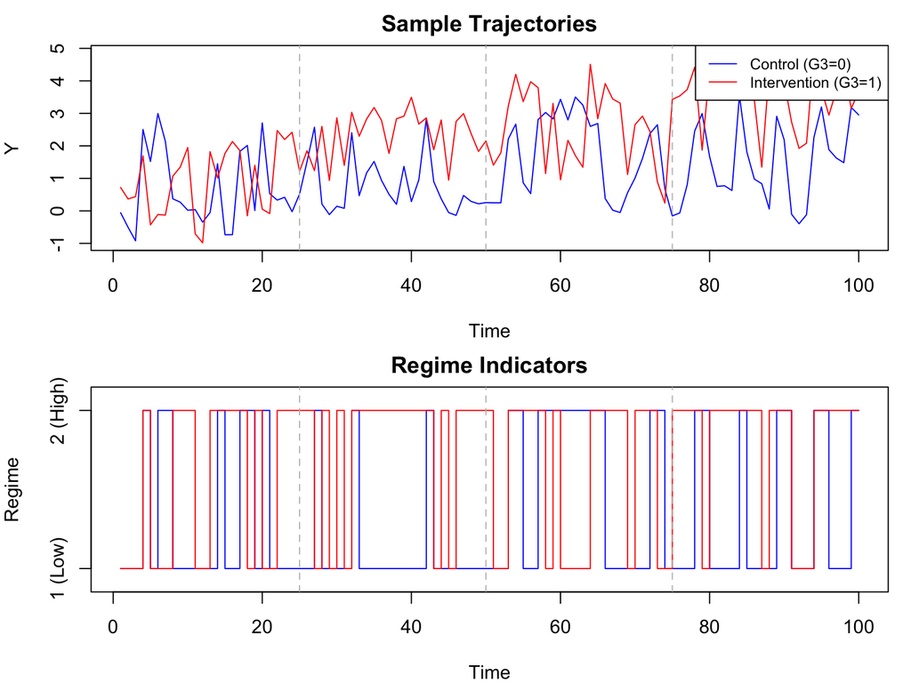

Sample trajectories from simulated data. Top: Time series for selected individuals. Bottom: Regime indicators (1 = low, 2 = high).

```r
# Plot sample trajectories
par(mfrow = c(2, 1), mar = c(4, 4, 2, 1))

# Select a few persons to display
sample_ids <- c(1, 26)  # One from each group

# Plot time series
plot(1:simdata$O, simdata$Y[sample_ids[1], ], type = "l", col = "blue",
     ylim = range(simdata$Y[sample_ids, ]),
     xlab = "Time", ylab = "Y", main = "Sample Trajectories")
lines(1:simdata$O, simdata$Y[sample_ids[2], ], col = "red")
legend("topright", legend = c("Control (G3=0)", "Intervention (G3=1)"),
       col = c("blue", "red"), lty = 1, cex = 0.8)

# Add period boundaries
abline(v = c(25, 50, 75), lty = 2, col = "gray")

# Plot regime indicators
plot(1:simdata$O, simdata$midx[sample_ids[1], ], type = "s", col = "blue",
     ylim = c(0.9, 2.1), xlab = "Time", ylab = "Regime",
     main = "Regime Indicators", yaxt = "n")
lines(1:simdata$O, simdata$midx[sample_ids[2], ], type = "s", col = "red")
axis(2, at = c(1, 2), labels = c("1 (Low)", "2 (High)"))
abline(v = c(25, 50, 75), lty = 2, col = "gray")
```

# 4 Part 2: Model Fitting with JAGS

## 4.1 JAGS Model Specification

The following JAGS model implements the GCM-RS2 framework. The model is saved to a temporary file for use with `jags.model()`.

```r
# Define JAGS model as a string
jags_model_string <- "
model{
for (pp in 1:P) {

## odds: transition probability matrices
## midx: regime indicators

# 1st observation
odds[pp,1,1] <- 0.9
odds[pp,1,2] <- 0.1

midx[pp,1] ~ dcat(odds[pp,1,])

Y[pp,1] ~ dnorm(0, 1)
beta0[pp] ~ dnorm(beta00, tau_beta0)
beta1[pp] ~ dnorm(beta10, tau_beta1)
AR[pp] ~ dnorm(AR0, tau_AR)T(-1,1)
sd_noise[pp] ~ dnorm(sd_noise0, tau_sd_noise)
tau_noise[pp] = pow(sd_noise[pp], -2)
gamma[1,pp] = 0
gamma[2,pp] ~ dnorm(gamma0[2], tau_gamma[2])


# from T2 to maxT[pp]
 for (bb in 1:nrPeriod){

   intercept[pp,bb] = beta0[pp] + beta1[pp]*time[bb]

   for(tt in (nrObs[bb]+1):nrObs[bb+1]){

# from regime midx[pp,tt-1] to regime 1
odds[pp,tt,1] <- exp(alpha[1,1,midx[pp,tt-1]]+alpha[2,1,midx[pp,tt-1]]*Period2[tt]*G3[pp])
# from regime midx[pp,tt-1] to regime 2
odds[pp,tt,2] <- exp(alpha[1,2,midx[pp,tt-1]]+alpha[2,2,midx[pp,tt-1]]*Period2[tt]*G3[pp])

midx[pp,tt] ~ dcat(odds[pp,tt,])

mus[pp,tt] <- gamma[midx[pp,tt],pp] + intercept[pp,bb] + AR[pp] * (Y[pp,tt-1] - intercept[pp,bb] - gamma[midx[pp,tt-1],pp])

Y[pp,tt] ~ dnorm(mus[pp,tt], tau_noise[pp])


} # close loop over time points

}

} # close loop over persons

# priors
gamma0[2] ~ dnorm(0, 0.01)T(0,)
tau_gamma[2] ~ dgamma(0.001,0.001)
sd_gamma[2] = pow(tau_gamma[2], -1/2)

AR0 ~ dnorm(0,1)T(-1,1)
sd_AR ~ dunif(0, 1)
tau_AR = pow(sd_AR, -2)

sd_noise0 ~ dunif(0, 1)
sd_sd_noise ~ dunif(0, 1)
tau_sd_noise = pow(sd_sd_noise, -2)

beta00 ~ dnorm(0, 0.01)
tau_beta0 ~ dgamma(0.001,0.001)
sd_beta0 = pow(tau_beta0, -1/2)
beta10 ~ dnorm(0, 0.01)
tau_beta1 ~ dgamma(0.001,0.001)
sd_beta1 = pow(tau_beta1, -1/2)

for(kk in 1:2){
  alpha[kk,2,1] ~ dnorm(0,0.1)
  alpha[kk,1,1] <- 0
  alpha[kk,1,2] ~ dnorm(0,0.1)
  alpha[kk,2,2] <- 0
}


} # end of model
"

# Write model to a temporary file
model_file <- tempfile(fileext = ".txt")
writeLines(jags_model_string, model_file)
cat("JAGS model saved to:", model_file, "\n")
```

```
## JAGS model saved to: /var/folders/2d/_q9vyqbn7kbcqkv196fzxktc0000gn/T//Rtmpr3ntZt/file126e9534e893b.txt
```

## 4.2 Prepare Data for JAGS

```r
# Prepare data list for JAGS
jags_data <- list(
  Y = simdata$Y,
  P = simdata$N,
  maxT = simdata$O,
  Period2 = simdata$Period2,
  time = simdata$time,
  nrObs = simdata$nrObs,
  nrPeriod = simdata$nrPeriod,
  G3 = simdata$G3
)

# Display data structure
str(jags_data)
```

```
## List of 8
##  $ Y       : num [1:50, 1:100] -0.05734 -0.32531 0.45536 -0.00739 0.01506 ...
##  $ P       : num 50
##  $ maxT    : num 100
##  $ Period2 : num [1:100] 0 0 0 0 0 0 0 0 0 0 ...
##  $ time    : int [1:4] 0 1 2 3
##  $ nrObs   : num [1:5] 1 25 50 75 100
##  $ nrPeriod: int 4
##  $ G3      : num [1:50] 0 0 0 0 0 0 0 0 0 0 ...
```

## 4.3 MCMC Settings

```r
# Fixed initial values for reproducibility
fixedinits <- list(
  list(.RNG.seed = 1, .RNG.name = "base::Mersenne-Twister"),
  list(.RNG.seed = 2, .RNG.name = "base::Mersenne-Twister")
)

# MCMC settings
n_chains <- 2        # Number of MCMC chains
n_adapt <- 4000      # Adaptation iterations
n_burnin <- 1000     # Burn-in iterations
n_iter <- 20000      # Sampling iterations

# Parameters to monitor
parameterlist <- c(
  "beta00", "sd_beta0",         # GCM intercept parameters
  "beta10", "sd_beta1",         # GCM slope parameters
  "AR0", "sd_AR",               # AR parameters
  "sd_noise0", "sd_sd_noise",   # Process noise parameters
  "gamma0", "sd_gamma",         # Regime shift parameters
  "AR", "sd_noise",             # Person-specific parameters
  "alpha",                      # Transition parameters
  "midx",                       # Regime indicators
  "deviance"                    # Model fit
)
```

## 4.4 Run JAGS Model

```r
# Initialize JAGS model
cat("Initializing JAGS model...\n")
jagsModel <- jags.model(
  file = model_file,
  data = jags_data,
  inits = fixedinits,
  n.chains = n_chains,
  n.adapt = n_adapt
)

# Burn-in period
cat("Running burn-in (", n_burnin, " iterations)...\n", sep = "")
update(jagsModel, n.iter = n_burnin)

# Sample from posterior
cat("Sampling from posterior (", n_iter, " iterations)...\n", sep = "")
codaSamples <- coda.samples(
  jagsModel,
  variable.names = parameterlist,
  n.iter = n_iter
)

cat("MCMC sampling complete.\n")
```

# 5 Part 3: Post-Analysis

## 5.1 Generate Summary Table

```r
# Generate comprehensive summary using zcalc
resulttable <- zcalc(codaSamples)

# Display fixed-effect parameters
fixed_params <- c("beta00", "sd_beta0", "beta10", "sd_beta1",
                  "AR0", "sd_AR", "sd_noise0", "sd_sd_noise",
                  "gamma0[2]", "sd_gamma[2]",
                  "alpha[1,2,1]", "alpha[2,2,1]",
                  "alpha[1,1,2]", "alpha[2,1,2]")

# Extract rows for fixed parameters
fixed_rows <- resulttable[rownames(resulttable) %in% fixed_params, ]

cat("\n=== Fixed-Effect Parameter Estimates ===\n")
```

```
##
## === Fixed-Effect Parameter Estimates ===
```

```r
print(fixed_rows[, c("mean", "sd", "95% HDI_L", "95% HDI_H", "ESS", "RHAT")])
```

```
##                 mean     sd 95% HDI_L 95% HDI_H   ESS   RHAT
## AR0           0.3203 0.0195    0.2814    0.3575  1427 1.0008
## alpha[1,2,1] -0.4949 0.0468   -0.5872   -0.4034 16947 1.0001
## alpha[2,2,1]  1.2644 0.1961    0.8814    1.6523 17231 1.0000
## alpha[1,1,2] -0.5407 0.0472   -0.6317   -0.4478 15777 1.0000
## alpha[2,1,2] -1.0035 0.1341   -1.2641   -0.7380 16298 1.0000
## beta00       -0.0271 0.0294   -0.0838    0.0319  5743 1.0010
## beta10        0.4486 0.0287    0.3927    0.5060 18279 1.0001
## gamma0[2]     2.0354 0.0311    1.9751    2.0974 17301 1.0000
## sd_AR         0.0540 0.0292    0.0003    0.1027   323 1.0046
## sd_beta0      0.1406 0.0289    0.0856    0.1989  2686 1.0007
## sd_beta1      0.1884 0.0224    0.1480    0.2345 14056 1.0000
## sd_gamma[2]   0.1865 0.0251    0.1399    0.2369 13390 1.0000
## sd_noise0     0.5034 0.0145    0.4752    0.5326 15153 1.0000
## sd_sd_noise   0.0931 0.0121    0.0701    0.1167  8792 1.0006
```

## 5.2 Parameter Recovery Assessment

```r
# True parameter values
# Note: gamma0[2] corresponds to Δ_{μ,2} in the paper (regime shift magnitude)
true_values <- c(
  beta00 = simdata$beta00,
  sd_beta0 = simdata$sd_beta0,
  beta10 = simdata$beta10,
  sd_beta1 = simdata$sd_beta1,
  AR0 = simdata$AR0,
  sd_AR = simdata$sd_AR,
  sd_noise0 = simdata$sd_noise0,
  sd_sd_noise = simdata$sd_sd_noise,
  `gamma0[2]` = simdata$gamma0[2],
  sd_gamma_2 = simdata$sd_gamma[2],
  `alpha[1,2,1]` = simdata$alpha[1, 2, 1],
  `alpha[2,2,1]` = simdata$alpha[2, 2, 1],
  `alpha[1,1,2]` = simdata$alpha[1, 1, 2],
  `alpha[2,1,2]` = simdata$alpha[2, 1, 2]
)

# Create comparison table
param_names <- names(true_values)
recovery_table <- data.frame(
  Parameter = param_names,
  True = unname(true_values),
  Estimate = resulttable[match(param_names, rownames(resulttable)), "mean"],
  SD = resulttable[match(param_names, rownames(resulttable)), "sd"],
  HDI_Low = resulttable[match(param_names, rownames(resulttable)), "95% HDI_L"],
  HDI_High = resulttable[match(param_names, rownames(resulttable)), "95% HDI_H"],
  stringsAsFactors = FALSE
)

# Calculate bias and coverage
recovery_table$Bias <- recovery_table$Estimate - recovery_table$True
recovery_table$Covered <- with(recovery_table,
                               True >= HDI_Low & True <= HDI_High)

cat("\n=== Parameter Recovery Summary ===\n")
```

```
##
## === Parameter Recovery Summary ===
```

```r
print(recovery_table, row.names = FALSE)
```

```
##     Parameter True Estimate     SD HDI_Low HDI_High    Bias Covered
##        beta00  0.0  -0.0271 0.0294 -0.0838   0.0319 -0.0271    TRUE
##      sd_beta0  0.2   0.1406 0.0289  0.0856   0.1989 -0.0594   FALSE
##        beta10  0.5   0.4486 0.0287  0.3927   0.5060 -0.0514    TRUE
##      sd_beta1  0.2   0.1884 0.0224  0.1480   0.2345 -0.0116    TRUE
##           AR0  0.3   0.3203 0.0195  0.2814   0.3575  0.0203    TRUE
##         sd_AR  0.1   0.0540 0.0292  0.0003   0.1027 -0.0460    TRUE
##     sd_noise0  0.5   0.5034 0.0145  0.4752   0.5326  0.0034    TRUE
##   sd_sd_noise  0.1   0.0931 0.0121  0.0701   0.1167 -0.0069    TRUE
##     gamma0[2]  2.0   2.0354 0.0311  1.9751   2.0974  0.0354    TRUE
##    sd_gamma_2  0.2       NA     NA      NA       NA      NA      NA
##  alpha[1,2,1] -0.5  -0.4949 0.0468 -0.5872  -0.4034  0.0051    TRUE
##  alpha[2,2,1]  1.0   1.2644 0.1961  0.8814   1.6523  0.2644    TRUE
##  alpha[1,1,2] -0.5  -0.5407 0.0472 -0.6317  -0.4478 -0.0407    TRUE
##  alpha[2,1,2] -1.0  -1.0035 0.1341 -1.2641  -0.7380 -0.0035    TRUE
```

## 5.3 Model Fit and Entropy

```r
# Extract regime probabilities from posterior means
midx_rows <- grep("^midx", rownames(resulttable))
pr2 <- resulttable[midx_rows, "mean"] - 1  # Probability of regime 2
pr1 <- 1 - pr2                              # Probability of regime 1

# Calculate entropy
# E_k = 1 + sum(p*log(p)) / (N*T*log(K))
# For K=2 regimes
N <- simdata$N
O <- simdata$O

entropy <- 1 + (sum(pr2 * log(pr2), na.rm = TRUE) +
                sum(pr1 * log(pr1), na.rm = TRUE)) / (N * O * log(2))

# Deviance and Information Criteria
deviance <- resulttable[grep("deviance", rownames(resulttable)), "mean"]

# Number of parameters (npar) for GCM-RS2 model:
# Fixed effects: beta00, beta10, AR0, sd_noise0, gamma0[2] = 5
# Random effect SDs: sd_beta0, sd_beta1, sd_AR, sd_sd_noise, sd_gamma[2] = 5
# RS log-odds coefficients: alpha[1,2,1], alpha[2,2,1], alpha[1,1,2], alpha[2,1,2] = 4
# Total: 14 fixed parameters
npar <- 14

# Calculate IC measures (following Equations 8-10 in the paper)
# Note: Deviance = -2 * log-likelihood
AIC <- 2 * npar + deviance
BIC <- npar * log(N * O) + deviance
sBIC <- npar * log(N * O * (N * O + 2) / 24) + deviance

cat("\n=== Model Fit Diagnostics ===\n")
```

```
##
## === Model Fit Diagnostics ===
```

```r
cat("\n--- Information Criteria ---\n")
```

```
##
## --- Information Criteria ---
```

```r
cat("AIC:", round(AIC, 2), "\n")
```

```
## AIC:
```

```r
cat("BIC:", round(BIC, 2), "\n")
```

```
## BIC:
```

```r
cat("sBIC (sample-size adjusted BIC):", round(sBIC, 2), "\n")
```

```
## sBIC (sample-size adjusted BIC):
```

```r
cat("  Note: Lower values indicate better fit; differences > 2 are meaningful\n")
```

```
##   Note: Lower values indicate better fit; differences > 2 are meaningful
```

```r
cat("\n--- Entropy ---\n")
```

```
##
## --- Entropy ---
```

```r
cat("Entropy:", round(entropy, 4), "\n")
```

```
## Entropy: 0.8999
```

```r
cat("  (Values closer to 1 indicate clearer regime separation;\n")
```

```
##   (Values closer to 1 indicate clearer regime separation;
```

```r
cat("   values > 0.6 are generally considered acceptable for RS models)\n")
```

```
##    values > 0.6 are generally considered acceptable for RS models)
```

```r
cat("\nDeviance:", round(deviance, 2), "\n")
```

```
##
## Deviance:
```

```r
# Create summary table of model fit diagnostics
fit_summary <- data.frame(
  Metric = c("AIC", "BIC", "sBIC", "Entropy", "Deviance"),
  Value = c(round(AIC, 2), round(BIC, 2), round(sBIC, 2),
            round(entropy, 4), round(deviance, 2)),
  Description = c(
    "Akaike Information Criterion",
    "Bayesian Information Criterion",
    "Sample-size adjusted BIC",
    "Regime classification clarity (0-1)",
    "-2 * log-likelihood"
  )
)

cat("\n--- Summary Table ---\n")
```

```
##
## --- Summary Table ---
```

```r
print(fit_summary, row.names = FALSE)
```

```
##    Metric  Value                         Description
##       AIC 0.8999        Akaike Information Criterion
##       BIC 0.8999      Bayesian Information Criterion
##      sBIC 0.8999            Sample-size adjusted BIC
##   Entropy 0.8999 Regime classification clarity (0-1)
##  Deviance 0.8999                 -2 * log-likelihood
```

## 5.4 Classification Accuracy

```r
# Compare estimated vs. true regime indicators
midx_est <- resulttable[midx_rows, "median"]
midx_true <- as.vector(simdata$midx)

# Confusion matrix
TP <- sum(midx_true == 2 & round(midx_est) == 2)
TN <- sum(midx_true == 1 & round(midx_est) == 1)
FP <- sum(midx_true == 1 & round(midx_est) == 2)
FN <- sum(midx_true == 2 & round(midx_est) == 1)

# Calculate metrics
accuracy <- (TP + TN) / (N * O)
recall <- TP / (TP + FN)
precision <- TP / (TP + FP)

cat("\n=== Regime Classification Performance ===\n")
```

```
##
## === Regime Classification Performance ===
```

```r
cat("Accuracy:", round(accuracy, 4), "\n")
```

```
## Accuracy: 0.9734
```

```r
cat("Recall (Sensitivity):", round(recall, 4), "\n")
```

```
## Recall (Sensitivity): 0.9805
```

```r
cat("Precision:", round(precision, 4), "\n")
```

```
## Precision: 0.9699
```

## 5.5 Convergence Diagnostics

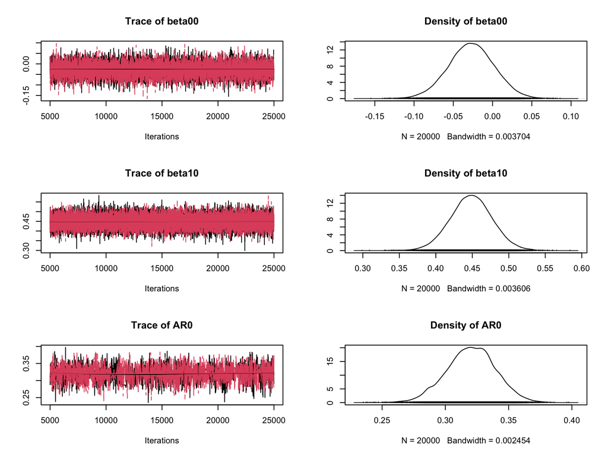

Trace plots and density plots for key parameters.

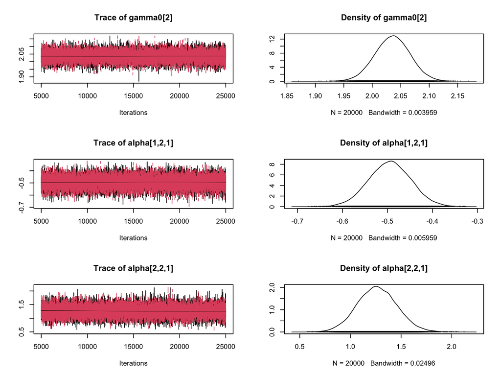

Trace plots and density plots for key parameters.

```r
# Select key parameters for visualization
key_params <- c("beta00", "beta10", "AR0", "gamma0[2]", "alpha[1,2,1]", "alpha[2,2,1]")

# Extract samples for key parameters
samples_subset <- codaSamples[, key_params]

# Plot trace and density
plot(samples_subset)
```

## 5.6 RHAT Summary

```r
# Check convergence via RHAT
max_rhat <- max(resulttable$RHAT, na.rm = TRUE)
n_high_rhat <- sum(resulttable$RHAT > 1.1, na.rm = TRUE)

cat("\n=== Convergence Summary ===\n")
```

```
##
## === Convergence Summary ===
```

```r
cat("Maximum RHAT:", round(max_rhat, 4), "\n")
```

```
## Maximum RHAT: 1.0046
```

```r
cat("Parameters with RHAT > 1.1:", n_high_rhat, "\n")
```

```
## Parameters with RHAT > 1.1: 0
```

```r
if (max_rhat < 1.1) {
  cat("Conclusion: All chains appear to have converged.\n")
} else {
  cat("Warning: Some parameters may not have converged. Consider longer runs.\n")
}
```

```
## Conclusion: All chains appear to have converged.
```

# 6 Summary

The results demonstrate satisfactory parameter recovery and regime classification under the simulated conditions with $N = 50$ and $T = 100$.

# 8 References

- Kruschke, J. (2014). *Doing Bayesian data analysis: A tutorial with R, JAGS, and Stan*. Academic Press.
- Li, Y., Williams, L., Muth, C., Heshmati, S., Chow, S.-M., & Oravecz, Z. (2024). A growth of hierarchical autoregression model for capturing individual differences in changes of dynamic characteristics of psychological processes. *Structural Equation Modeling: A Multidisciplinary Journal*, 32, 1–14.
- Plummer, M. (2003). JAGS: A program for analysis of Bayesian graphical models using Gibbs sampling. In *Proceedings of the 3rd International Workshop on Distributed Statistical Computing*.